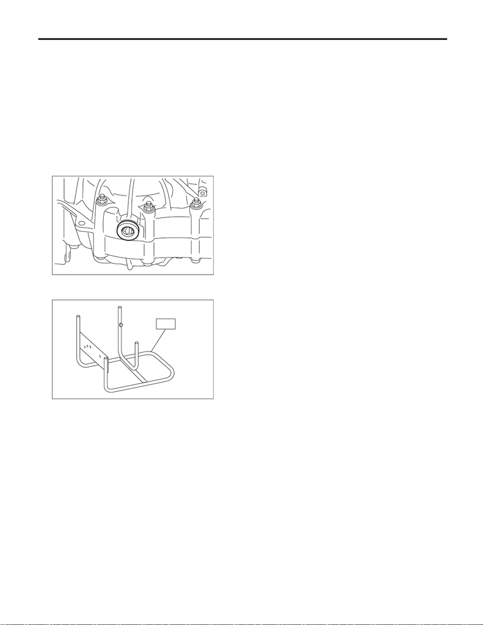

6MT(TY75)-50

Preparation for Overhaul

MANUAL TRANSMISSION AND DIFFERENTIAL

9. Preparation for Overhaul

A: PROCEDURE

1) Clean oil, grease, dirt and dust from the transmission.

2) Using the TORX

®

bit T70, remove the drain plug, and drain the transmission gear oil completely.

3) Tighten the drain plug using TORX

®

bit T70.

NOTE:

Use a new gasket.

Tightening torque:

44 N·m (4.5 kgf-m, 32.5 ft-lb) (aluminum gasket, silver)

70 N·m (7.1 kgf-m, 51.6 ft-lb) (copper gasket, brown)

70 N·m (7.1 kgf-m, 51.6 ft-lb) (metal gasket, black)

4) Attach the transmission to the ST.

ST 499937100 TRANSMISSION STAND

5) Apply oil to rotating parts before assembly.

6) All disassembled parts, if to be reused, should be reinstalled in the original positions and directions.

7) Gaskets, lock washers and lock nuts must be replaced with new ones.

8) Apply liquid gasket to the specified areas to prevent leakage.

MT-01548

MT-00115

ST